# Chapter 1: Data Visualisation with ggplot2

David Clark

26/04/2018

## Loading in packages and data frames

First, we’re going to load in the **tidyverse** pacakge, which will in turn load in other packages that are useful in the data preparation stage.

```r
library(tidyverse)
```

Within the **ggplot2** package is the dataset *mpg*. We can look at a subsample of the data (in a data frame termed a *tibble*) by simple running the name of the dataset as a command:

```r
mpg
```

| manufacturer | model | displ | year | cyl | trans | drv | cty | hwy | fl | class |
| --- | --- | --- | --- | --- | --- | --- | --- | --- | --- | --- |
| audi | a4 | 1.8 | 1999 | 4 | auto(l5) | f | 18 | 29 | p | compact |
| audi | a4 | 1.8 | 1999 | 4 | manual(m5) | f | 21 | 29 | p | compact |
| audi | a4 | 2.0 | 2008 | 4 | manual(m6) | f | 20 | 31 | p | compact |
| audi | a4 | 2.0 | 2008 | 4 | auto(av) | f | 21 | 30 | p | compact |
| audi | a4 | 2.8 | 1999 | 6 | auto(l5) | f | 16 | 26 | p | compact |
| audi | a4 | 2.8 | 1999 | 6 | manual(m5) | f | 18 | 26 | p | compact |
| audi | a4 | 3.1 | 2008 | 6 | auto(av) | f | 18 | 27 | p | compact |
| audi | a4 quattro | 1.8 | 1999 | 4 | manual(m5) | 4 | 18 | 26 | p | compact |
| audi | a4 quattro | 1.8 | 1999 | 4 | auto(l5) | 4 | 16 | 25 | p | compact |
| audi | a4 quattro | 2.0 | 2008 | 4 | manual(m6) | 4 | 20 | 28 | p | compact |

[output cut: 224 more lines]

Whilst the name of most variables are self-explanatory:

## Creating a ggplot

For example, let us look at a scatter plot between *displ* and *hwy* using the ggplot2 package:

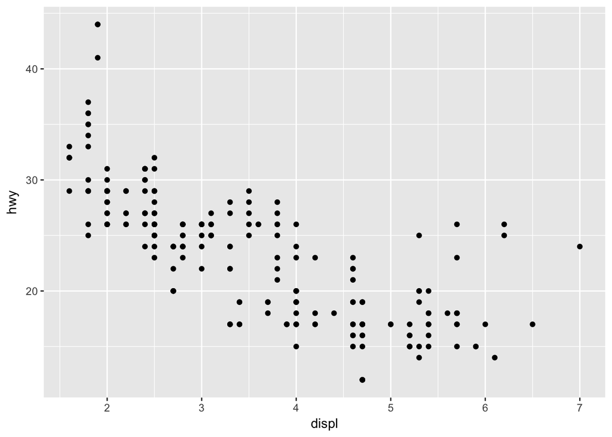

```r
ggplot(data = mpg) +
  geom_point(mapping = aes(x = displ, y = hwy))
```

The general syntax:

```r
ggplot(data = **x**) +
  geom_[**graph type**](mapping = aes(x = **xvar**, y = **yvar**))
```

The above plot is informative; it displays a negative association between both variables and the observations are distinct. That being said, what if we want to look and how these observations are distrbuted by another attributed, say by car type (*class*).

We can add to the asethetics to augment the plot, in order to be able to colour code the observations by *class*:

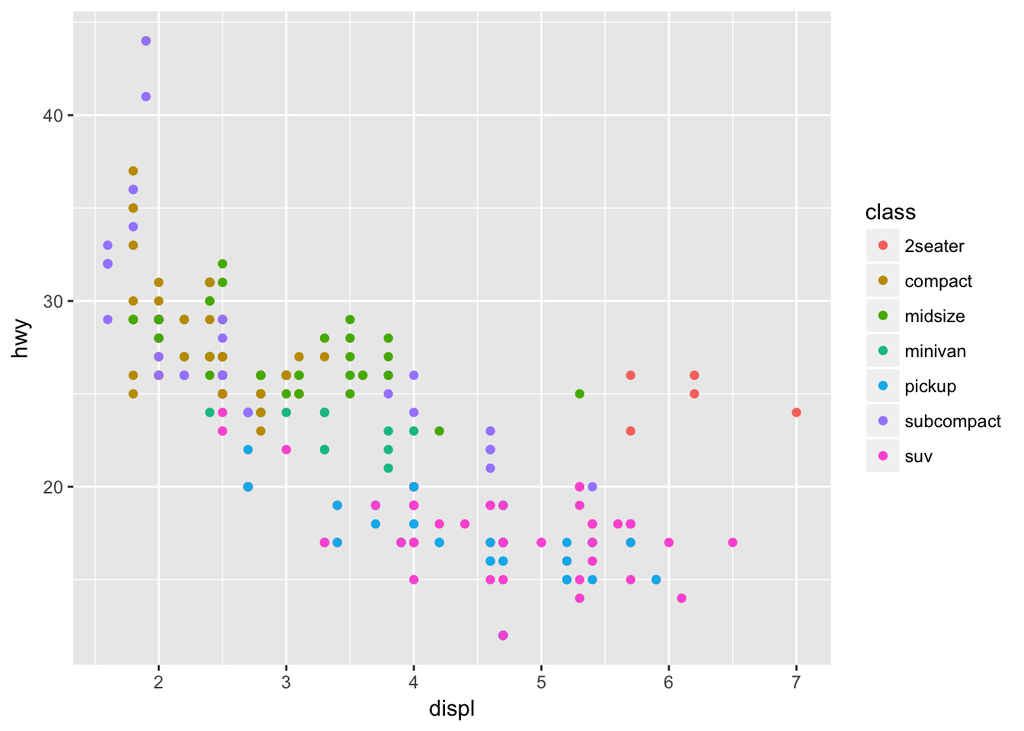

```r
ggplot(data = mpg) +
  geom_point(mapping = aes(x = displ, y = hwy, colour = class))
```

There are other options of identifying the class of the car other than colour.

We can augment the size of each data point corresponding to the car type, change the level of transparaency or use different shapes for the data points:

```
## Warning: Using size for a discrete variable is not advised.
```

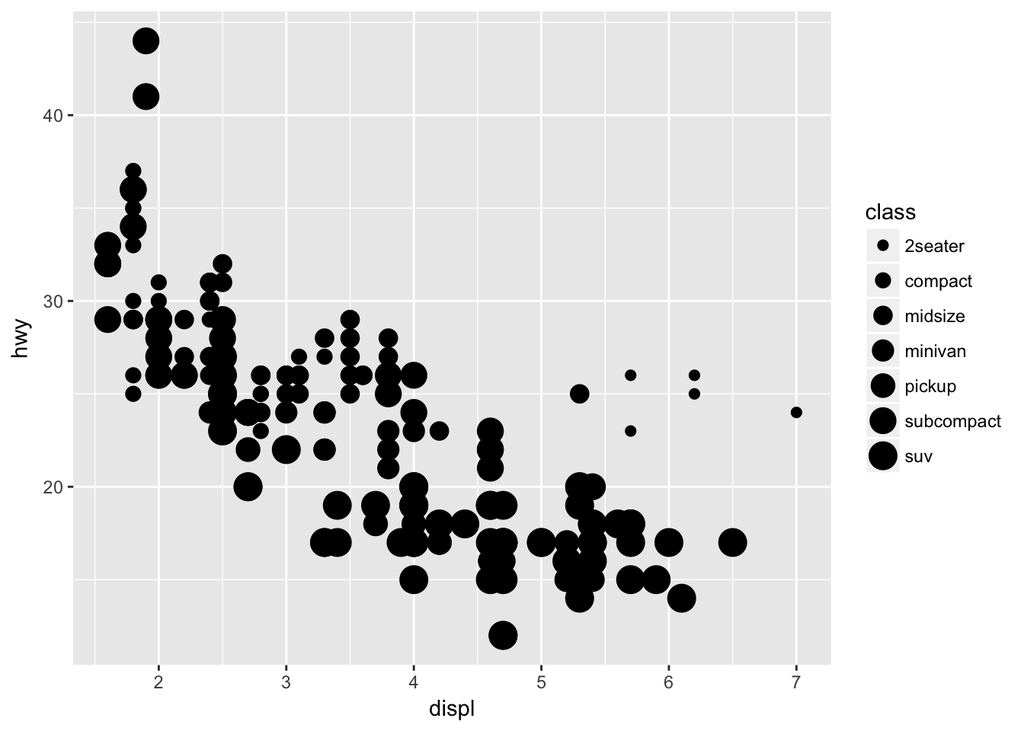

```r
ggplot(data = mpg) +
  geom_point(mapping = aes(x = displ, y = hwy, size = class))
```

The warning here is shown to signify the issue with using *discrete* data in line with the size aesthetic; generally uninformative.

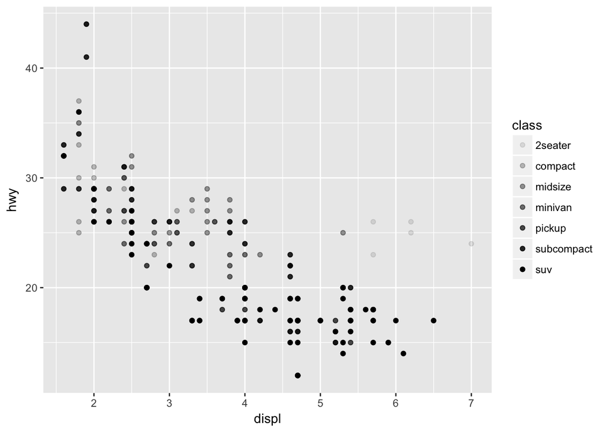

```r
ggplot(data = mpg) +
  geom_point(mapping = aes(x = displ, y = hwy, alpha = class))
```

```
## Warning: The shape palette can deal with a maximum of 6 discrete values
## because more than 6 becomes difficult to discriminate; you have 7.
## Consider specifying shapes manually if you must have them.
```

```
## Warning: Removed 62 rows containing missing values (geom_point).
```

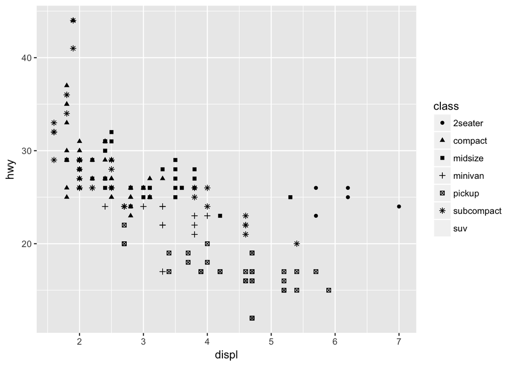

```r
ggplot(data = mpg) +
  geom_point(mapping = aes(x = displ, y = hwy, shape = class))
```

This warning is a little more serious; we essentially have too many classes and after the plotting of 6 classes, additional classes will not be plotted.

As an aside, if we are uninterested in the classification of groups in the plot, we can just choose to change the colour of all data points:

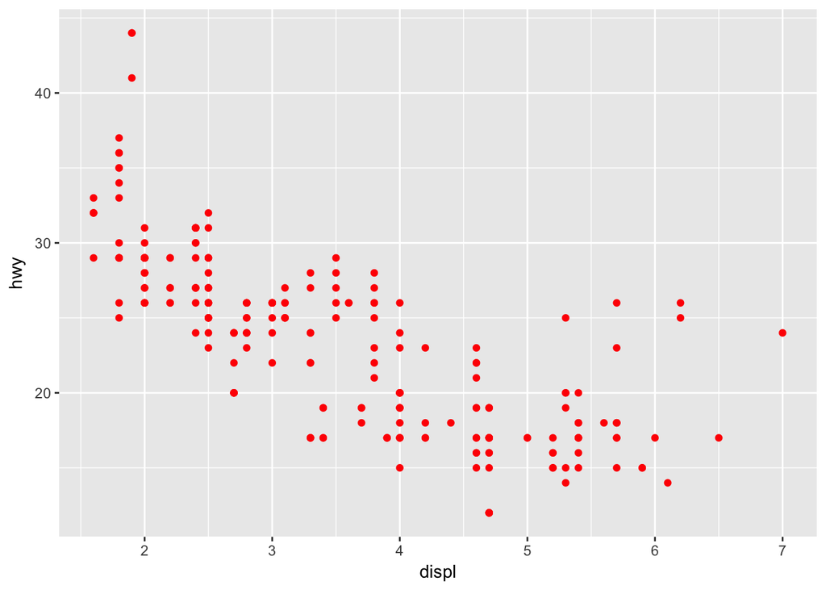

```r
ggplot(data = mpg) +
  geom_point(mapping = aes( x = displ, y = hwy), colour = "red")
```

Be careful - unlike the other options, the colour option require that the chosen option be surrounded by quotation marks. Notice also that this time, to set the aesthetic manually, the option is outside the aes().